# Missed reproductive events can reduce accuracy of uncertainty estimates in matrix population models

## Results: Accuracy

Accuracy metric: error i.e. difference between estimate and true value.

### Accuracy - by scenario and matrix size

Accuracy organised by scenario and matrix size (2x2, 3x3, 5x5).

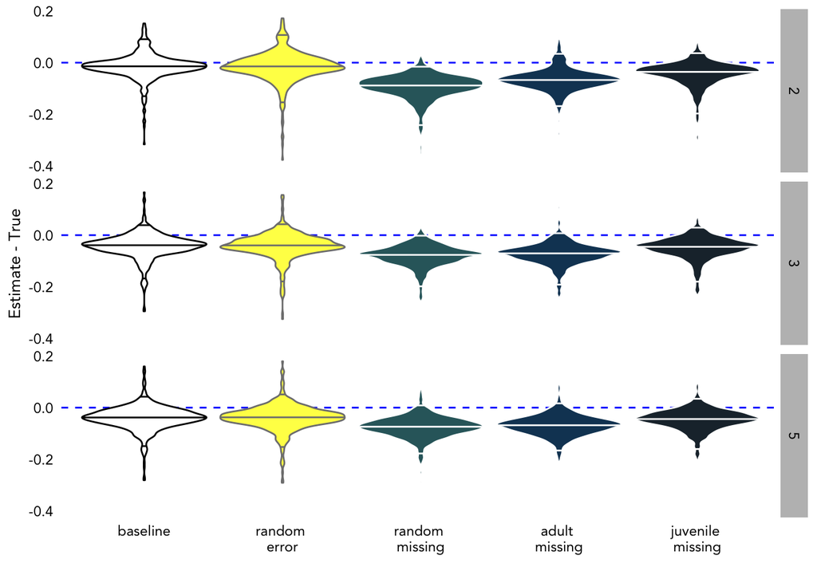

*Interpretation: matrix size has little impact on results, maybe slightly less impact of bias in the larger matrix (higher role of survival).*

### Accuracy - by scenario and fecundity importance

Accuracy organised by scenario and fecundity importance (1 = lowest, 5 = highest).

Just presented for 2x2 matrices.

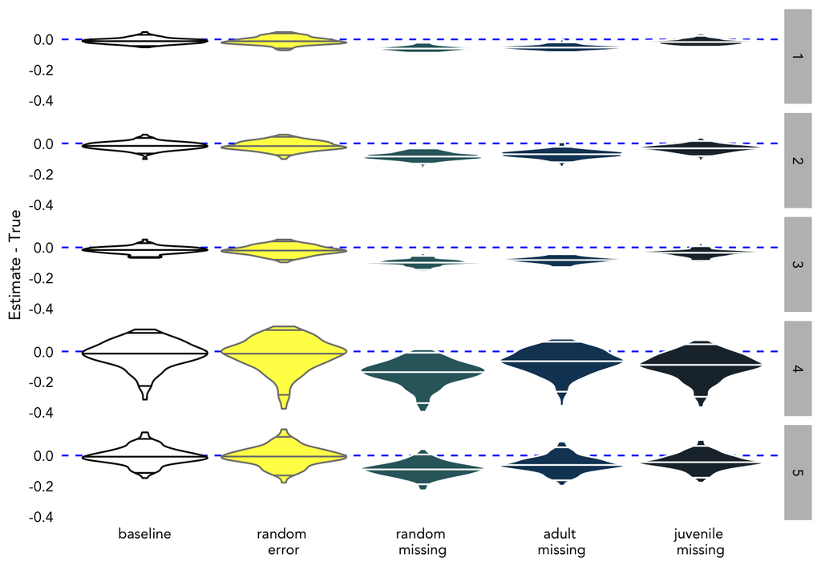

*Interpretation: Variability of error differs by matrix. Generally, there is more error in random error scenario but this is normally distributed. Can see most bias to estimate with random missing scenario and least for juvenile missing.*

## Results: Precision

Precision is measured by credible interval width.

### Precision - across all combos

Results shown for all matrices as all results are very similar. Little changes CI width.

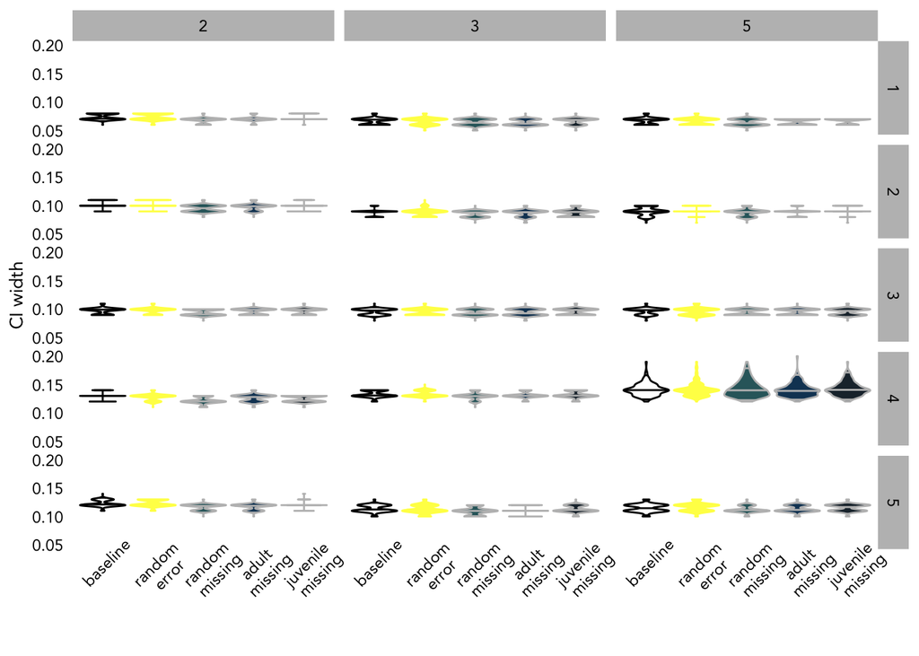

## Results: Coverage (accuracy of precision)

Coverage is the number of times the true parameter falls in the 95% credible interval. Would expect it to be 95% but this is not always the case.

This gives a measure of how accurate our precision metric is.

### Coverage - lambda by scenario

Coverage of lambda plotted with mean % for each scenario across all matrix sizes and fecundity importance.

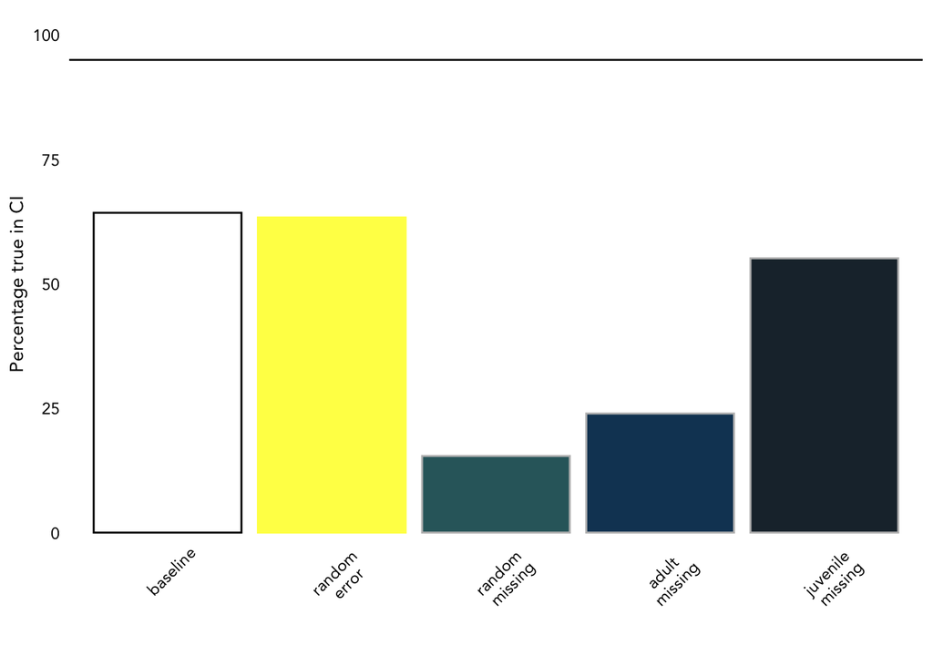

### Coverage - lambda by matrix size

Coverage of lambda plotted as mean % for matrix size across all fecundity levels.

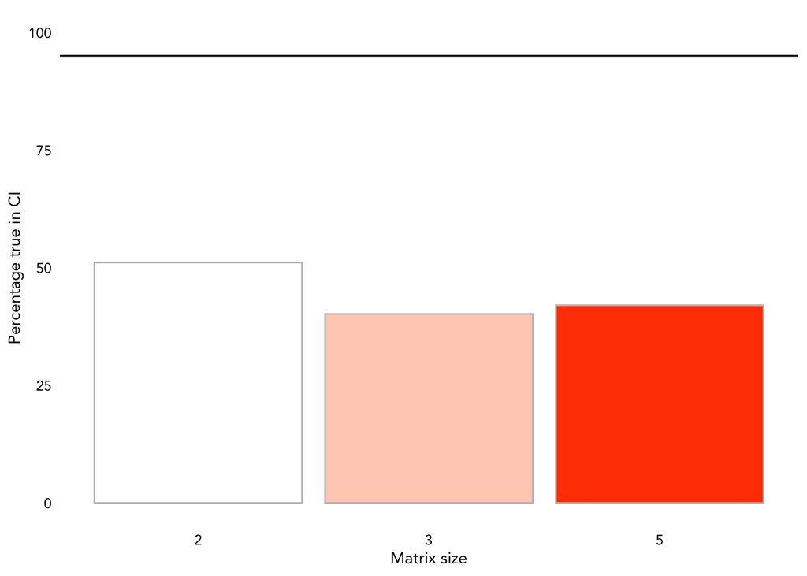

*Interpretation: As this is across all scenarios, the average % drops a lot. But is lowest for 3x3 matrices.*

### Coverage - lambda by fecundity ratio

Coverage of lambda plotted for 2x2 matrices only and facetted by fecundity importance (1 = lowest, 5 = highest).

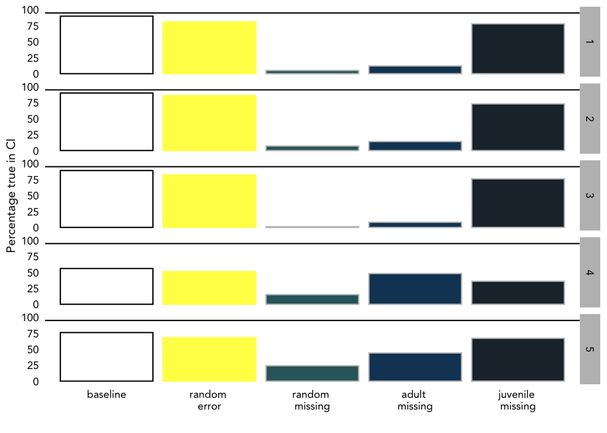

## Results: Comparison with direct estimation method

I also ran all scenarios through a model that directly estimates vital rates and then adds uncertainty through bootstrap. This more directly follows Caswell’s book but does not account for imperfect detection in survival.

As expected - just a sense check.

### Direct estimate error

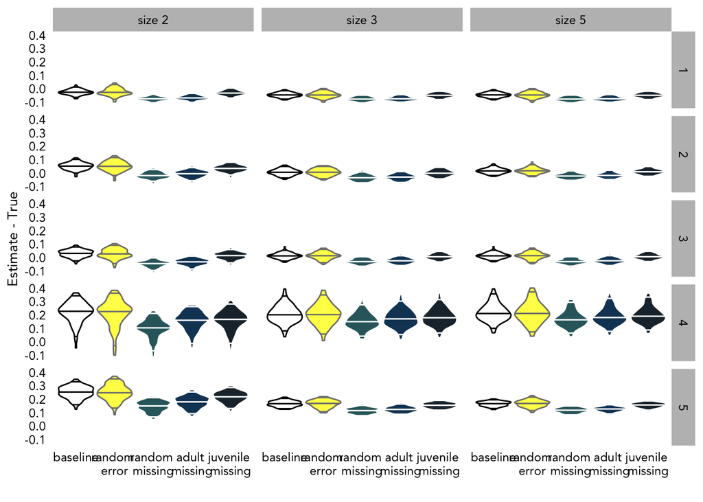

### Direct estimate CI width

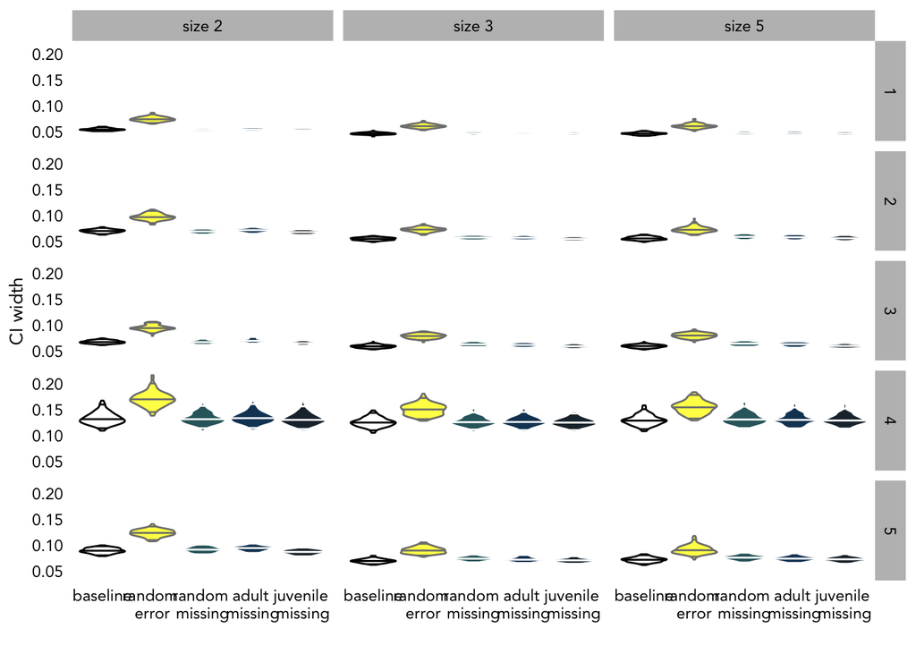

### Direct estimate coverage

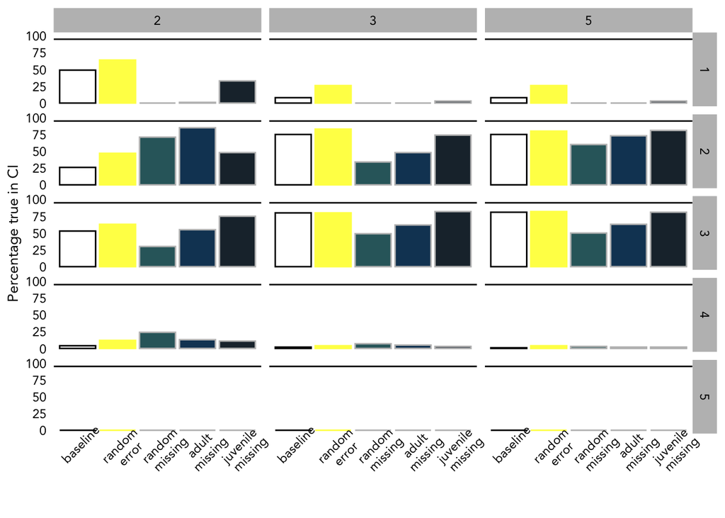